# Heatmap

Pumla

2024-06-18

#Setting up environment #Clean environment

```r
rm(list = ls(all.names = TRUE))
```

#load libraries

```r
library(DESeq2)
```

```r
library(pheatmap)
library(dplyr)
library(RColorBrewer)
library(ggplot2)
library(ggrepel)
```

#set the working directory

```r
setwd("~/inktset1/Heatmap")
```

#load the count data

```r
count_data <- read.csv('Counts.csv',header=TRUE,row.names=1)
```

#load the fpkm data

```r
fpkm_data <- read.csv('FPKM.csv', header=TRUE, row.names=1)
```

#check column names

```r
colnames(count_data)
```

```
## [1] "SRR13893218.bam" "SRR13893219.bam" "SRR13893220.bam" "SRR13893221.bam"
## [5] "SRR13893222.bam" "SRR13893223.bam"
```

```r
head(count_data, 50)
```

```
##                       SRR13893218.bam SRR13893219.bam SRR13893220.bam
## ENSMUSG00000102693.2                0               0               0
## ENSMUSG00000064842.3                0               0               0
## ENSMUSG00000051951.6                0               0               0
## ENSMUSG00000102851.2                0               0               0
## ENSMUSG00000103377.2                0               0               0
## ENSMUSG00000104017.2                0               0               0
## ENSMUSG00000103025.2                0               0               0
## ENSMUSG00000089699.2                0               0               0
## ENSMUSG00000103201.2                0               0               0
## ENSMUSG00000103147.2                0               0               1
## ENSMUSG00000103161.2                0               0               0
## ENSMUSG00000102331.2                0               1               0
## ENSMUSG00000102348.2                0               0               0
## ENSMUSG00000102592.2                0               0               0
## ENSMUSG00000088333.4                0               0               0
## ENSMUSG00000102343.2                0               0               0
## ENSMUSG00000025900.14               1               0               0
## ENSMUSG00000102948.2                0               0               0
## ENSMUSG00000104123.2                0               0               0
## ENSMUSG00000025902.14               0               0               0
## ENSMUSG00000104238.2                0               0               0
## ENSMUSG00000102269.2                5               4              12
## ENSMUSG00000118917.1                1               1               7
## ENSMUSG00000103003.2                0               0               0
## ENSMUSG00000104328.2                0               0              17
## ENSMUSG00000102735.2                1               2               1
## ENSMUSG00000098104.2              355             403             384
## ENSMUSG00000102175.2               17              10               0
## ENSMUSG00002075947.1                0               0               0
## ENSMUSG00000103265.2                4               4               0
## ENSMUSG00000103922.2               93             102              98
## ENSMUSG00000033845.14            5003            5035            3708
## ENSMUSG00000102275.2               14              20              61
## ENSMUSG00000120403.1               21              19               4
## ENSMUSG00000025903.15            2130            2095            2122
## ENSMUSG00000104217.2                0               0               0
## ENSMUSG00000033813.16            3265            3161            2938
## ENSMUSG00000062588.5               76              84             119
## ENSMUSG00000103280.2               13              16              37
```

[output cut: 47 more lines]

```
## ENSMUSG00000104217.2                0               0               0
## ENSMUSG00000033813.16            2855            3246            3343
## ENSMUSG00000062588.5              118              77              85
## ENSMUSG00000103280.2               34              50              63
## ENSMUSG00000002459.18               8              57              66
## ENSMUSG00000091305.2               10              15              10
## ENSMUSG00000102653.2                7               0               0
## ENSMUSG00000085623.2                0               0               0
## ENSMUSG00000091665.2                0               2               0
## ENSMUSG00000033793.13            3397            3573            3638
## ENSMUSG00000104352.2                0               0               1
## ENSMUSG00000104046.2                1              10               0
## ENSMUSG00000102907.2                0               6              14
## ENSMUSG00000025905.15               0               0               0
## ENSMUSG00000103936.2                0               0               0
```

#load the sample information

```r
sample_info <- read.csv('Design.csv',header=TRUE,row.names=1)
```

#ensure there are no missing values in your count data

```r
sum(is.na(count_data))
```

```
## [1] 0
```

```r
sum(is.na(sample_info))
```

```
## [1] 0
```

#set factor levels

```r
sample_info$Treatment <- factor(sample_info$Treatment)
```

#create a deseq object and import the count data and sample information

```r
dds <- DESeqDataSetFromMatrix(countData = count_data,colData = sample_info, design = ~Treatment)
```

```r
dds$Treatment <- factor(dds$Treatment, levels = c("healthy", "treated"))
```

#filter the genes based on count per sample

```r
keep <- rowSums(counts(dds) >= 10) >= 3
dds <- dds[keep,]
```

#perform the statistical test(s) to identify differentially expressed genes

```r
dds <- DESeq(dds)
deseq_result <- results(dds)
deseq_result
```

```
## log2 fold change (MLE): Treatment treated vs healthy
## Wald test p-value: Treatment treated vs healthy
## DataFrame with 21462 rows and 6 columns
##                        baseMean log2FoldChange     lfcSE      stat     pvalue
##                       <numeric>      <numeric> <numeric> <numeric>  <numeric>
## ENSMUSG00000098104.2   376.3213      -0.046894  0.144042 -0.325559 0.74475795
## ENSMUSG00000103922.2    85.0813      -0.319879  0.242484 -1.319176 0.18711033
## ENSMUSG00000033845.14 4428.9929       0.102163  0.143090  0.713974 0.47524356
## ENSMUSG00000102275.2    26.6758      -1.977045  0.829899 -2.382273 0.01720614
## ENSMUSG00000120403.1    27.7167       2.279930  0.741846  3.073319 0.00211692
## ...                         ...            ...       ...       ...        ...
## ENSMUSG00000079808.4   391.1776      -0.343524  0.169477 -2.026967  0.0426658
## ENSMUSG00000079222.3    37.4303      -1.869822  1.069698 -1.747991  0.0804657
## ENSMUSG00000062783.3   396.2326      -1.572729  0.696294 -2.258716  0.0239011
## ENSMUSG00002074899.1    21.3017      -1.604633  0.746037 -2.150876  0.0314860
## ENSMUSG00000095041.8  4214.9038       0.234792  0.319657  0.734512  0.4626369
##                            padj
##                       <numeric>
## ENSMUSG00000098104.2  0.8598140
## ENSMUSG00000103922.2  0.3594907
## ENSMUSG00000033845.14 0.6588939
## ENSMUSG00000102275.2  0.0603889
## ENSMUSG00000120403.1  0.0110356
## ...                         ...
## ENSMUSG00000079808.4  0.1221415
## ENSMUSG00000079222.3  0.1970059
## ENSMUSG00000062783.3  0.0780887
## ENSMUSG00002074899.1  0.0968127
## ENSMUSG00000095041.8  0.6473960
```

#change DESeq Object to R object(dataframe)

```r
deseq_result <- as.data.frame(deseq_result)
class(deseq_result)
```

```
## [1] "data.frame"
```

```r
head(deseq_result, 50)
```

```
##                          baseMean log2FoldChange      lfcSE          stat
## ENSMUSG00000098104.2   376.321282  -0.0468940229 0.14404150 -0.3255591102
## ENSMUSG00000103922.2    85.081329  -0.3198787765 0.24248380 -1.3191758647
## ENSMUSG00000033845.14 4428.992863   0.1021625214 0.14309007  0.7139735023
## ENSMUSG00000102275.2    26.675758  -1.9770448478 0.82989853 -2.3822729836
## ENSMUSG00000120403.1    27.716671   2.2799302450 0.74184635  3.0733186725
## ENSMUSG00000025903.15 2168.166030   0.1365024023 0.10215054  1.3362866279
## ENSMUSG00000033813.16 3121.941959   0.1183608320 0.06210873  1.9057035036
## ENSMUSG00000062588.5    93.566238  -0.2993721796 0.35407631 -0.8455018737
## ENSMUSG00000103280.2    35.789916   1.1566408367 0.61796702  1.8716870096
## ENSMUSG00000002459.18   31.492620   1.8922382649 0.64734378  2.9230809619
## ENSMUSG00000091305.2    15.107520  -0.3966003904 0.94817531 -0.4182774935
## ENSMUSG00000033793.13 4084.414345  -0.2619082900 0.22640356 -1.1568205543
## ENSMUSG00000090031.4  1672.409468   0.0001180672 0.16391790  0.0007202824
## ENSMUSG00000025907.15 6701.106961  -0.0070308186 0.13156692 -0.0534391065
## ENSMUSG00000103355.2    26.652406  -0.5336130330 0.51027397 -1.0457383054
## ENSMUSG00000103845.2    14.464108  -0.2191394947 0.71955835 -0.3045472177
## ENSMUSG00000102135.2  9256.043366  -0.1086752567 0.07596054 -1.4306804345
## ENSMUSG00000120372.1   259.352814  -0.6085288572 0.18046438 -3.3720164015
## ENSMUSG00000051285.18 5448.595632  -0.1812794108 0.08180015 -2.2161257551
## ENSMUSG00000098201.2   232.781850   0.0058193477 0.27534461  0.0211347802
## ENSMUSG00000103509.2   207.698308   0.2222324235 0.14621283  1.5199242010
## ENSMUSG00000048538.8    46.800859  -1.1349102735 0.46983850 -2.4155327397
## ENSMUSG00000097797.7   116.813729  -1.3178956676 0.54087203 -2.4366127309
## ENSMUSG00000104226.2    11.254545   0.6837650881 0.86281856  0.7924784148
## ENSMUSG00000103903.2    10.311150  -0.2914332703 0.77527715 -0.3759084979
## ENSMUSG00000084353.2   138.174318   0.1133824108 1.11095222  0.1020587645
## ENSMUSG00000103933.2   222.009997  -0.7152714883 0.66042497 -1.0830473188
## ENSMUSG00002075967.1   982.967484   0.2911013815 0.52350307  0.5560643224
## ENSMUSG00000102272.2    28.939063  -0.9841384593 0.41325467 -2.3814333766
## ENSMUSG00000061024.9  1388.611262  -0.0216941471 0.08280604 -0.2619874902
## ENSMUSG00000079671.10    9.742507   1.1867725061 0.77042494  1.5404128772
## ENSMUSG00000081441.4   692.416023   0.1261227895 0.15020367  0.8396784883
## ENSMUSG00000025912.17   53.710004   0.3455962929 0.31422247  1.0998458940
## ENSMUSG00000045210.9  2269.242167   0.3703904615 0.12651873  2.9275542675
## ENSMUSG00000097893.10   21.054744  -0.7466493577 0.48870972 -1.5277972477
## ENSMUSG00000025915.15 1005.424654  -2.2159525397 0.65784530 -3.3685009995
## ENSMUSG00000046334.5    10.750321   0.3326068671 0.93916289  0.3541524823
## ENSMUSG00000098234.9   793.409641  -0.2334208886 0.32303241 -0.7225927896
## ENSMUSG00000046101.17   27.524574  -2.8118911652 0.61074902 -4.6040043855
```

[output cut: 47 more lines]

```
## ENSMUSG00000025915.15 7.557812e-04 4.704344e-03
## ENSMUSG00000046334.5  7.232246e-01 8.450214e-01
## ENSMUSG00000098234.9  4.699301e-01 6.538229e-01
## ENSMUSG00000046101.17 4.144437e-06 5.410457e-05
## ENSMUSG00000025917.10 6.247029e-01 7.759346e-01
## ENSMUSG00000056763.17 2.119262e-01 3.905848e-01
## ENSMUSG00000067851.12 5.100822e-01 6.874338e-01
## ENSMUSG00002076532.1  7.190888e-02 1.814376e-01
## ENSMUSG00000102556.2  7.675083e-07 1.183352e-05
## ENSMUSG00000100648.2  9.445636e-01 9.740764e-01
## ENSMUSG00000025938.17 2.130303e-02 7.127134e-02
## ENSMUSG00000005886.15 9.965172e-01 9.984712e-01
## ENSMUSG00000103506.2  2.960114e-01 4.859195e-01
## ENSMUSG00000103495.2  4.042664e-16 2.390183e-14
## ENSMUSG00002076346.1  9.059244e-01 9.538339e-01
```

#Order the results table by increasing p-value (the lowest p-value first, most statistically significant appearing first)

```r
deseq_result_ordered <- deseq_result[order(deseq_result$pvalue),]
head(deseq_result_ordered, 50)
```

```
##                          baseMean log2FoldChange      lfcSE      stat
## ENSMUSG00000014599.11   2635.1079      3.5198372 0.08004937  43.97083
## ENSMUSG00000029075.7    2188.7595      4.4532126 0.11044434  40.32088
## ENSMUSG00000052336.9    1012.3440      5.0102147 0.14066783  35.61735
## ENSMUSG00000120236.1     844.5704      5.3547123 0.15891494  33.69546
## ENSMUSG00000020027.19   9736.7140     -1.6122603 0.05026990 -32.07208
## ENSMUSG00000045087.9    1099.5302      4.8073774 0.17030057  28.22878
## ENSMUSG00000030114.9    2231.4705      4.1249559 0.15093367  27.32959
## ENSMUSG00000054072.13    805.7105      2.5556678 0.10448220  24.46032
## ENSMUSG00000121360.1     598.9740      3.4508656 0.14116014  24.44646
## ENSMUSG00000073940.4  397482.3899     -1.5241427 0.06435818 -23.68219
## ENSMUSG00000033016.17   6549.9314      1.2137859 0.05167000  23.49112
## ENSMUSG00000046718.9    8816.4886     -1.0892662 0.04762717 -22.87069
## ENSMUSG00000000753.16    523.0318      3.3744014 0.14775466  22.83787
## ENSMUSG00000085519.2     347.7957      5.3887901 0.23782778  22.65837
## ENSMUSG00000018012.12    303.6414      6.0158282 0.27086607  22.20960
## ENSMUSG00000009588.10   2140.4334      2.1517215 0.09758965  22.04867
## ENSMUSG00000032437.11   6506.9765     -1.1669846 0.05325303 -21.91396
## ENSMUSG00000042379.9     371.0089      5.4398054 0.24909294  21.83846
## ENSMUSG00000002808.8     296.4089      5.0137631 0.22986081  21.81217
## ENSMUSG00000020399.15    335.8353      3.8691287 0.17900415  21.61474
## ENSMUSG00000000290.14  16280.7478      0.8866424 0.04166459  21.28048
## ENSMUSG00000069917.8  148955.2744     -1.0953171 0.05260369 -20.82206
## ENSMUSG00000021760.6     314.2022      5.9846534 0.28774890  20.79818
## ENSMUSG00000103432.2    2551.8103      1.4038224 0.06868604  20.43825
## ENSMUSG00000016529.6    2053.8292      5.7556895 0.28270583  20.35929
## ENSMUSG00000030122.14   9577.9327      2.6635011 0.13462335  19.78484
## ENSMUSG00000049109.16   1794.5741     -1.5129007 0.08054616 -18.78303
## ENSMUSG00000030124.3    5259.5143      5.3878367 0.28793070  18.71227
## ENSMUSG00000038151.14   1619.9207      1.4991643 0.08087362  18.53712
## ENSMUSG00000030154.11   1734.8032      1.4957132 0.08158760  18.33260
## ENSMUSG00000050974.5    1020.9561     -1.6516398 0.09136960 -18.07647
## ENSMUSG00000028634.18   2960.9097      1.2511948 0.06945013  18.01573
## ENSMUSG00000035021.15   9255.5729      0.9641285 0.05380021  17.92054
## ENSMUSG00000067219.10    417.6043      2.6586136 0.15005707  17.71735
## ENSMUSG00000026011.14   1919.7559      5.1165958 0.28967853  17.66301
## ENSMUSG00000044303.7     243.5600      2.6537312 0.15361006  17.27576
## ENSMUSG00000021549.15   8804.3618      1.3881189 0.08073211  17.19414
## ENSMUSG00000027718.9    1185.5544      6.1411153 0.36189916  16.96913
## ENSMUSG00000021411.17   4045.4013     -1.9295835 0.11499436 -16.77981
```

[output cut: 47 more lines]

```
## ENSMUSG00000044303.7   7.161856e-67  4.269660e-64
## ENSMUSG00000021549.15  2.938071e-66  1.704240e-63
## ENSMUSG00000027718.9   1.389670e-64  7.848711e-62
## ENSMUSG00000021411.17  3.429268e-63  1.887152e-60
## ENSMUSG00000045382.7   8.351764e-63  4.481139e-60
## ENSMUSG00000028565.19  1.053508e-62  5.514727e-60
## ENSMUSG00000004207.16  2.150145e-62  1.098724e-59
## ENSMUSG00000023004.9   1.026875e-60  5.125300e-58
## ENSMUSG00000029530.17  3.417414e-60  1.666921e-57
## ENSMUSG00000032446.15  8.362506e-60  3.988358e-57
## ENSMUSG00000000869.13  3.837769e-59  1.790569e-56
## ENSMUSG00000022584.15  1.205045e-58  5.502697e-56
## ENSMUSG00000068923.15  3.268422e-58  1.461393e-55
## ENSMUSG00000103693.2   4.870844e-58  2.133430e-55
## ENSMUSG00000024098.7   2.213725e-56  9.502194e-54
```

#extract the most differentially expressed genes due to the treatment #select genes with a significant change in gene expression (adjusted p-value below 0.05) #And log2fold change <1 and >1

#step 1: filter based on p adjusted values

```r
filtered <- deseq_result %>% filter(deseq_result$padj < 0.05)
```

#step 2: filter based on fold changes. here we will use a threshold of 1

```r
filtered <- filtered %>% filter(abs(filtered$log2FoldChange) > 1)
```

```r
dim(deseq_result)
```

```
## [1] 21462     6
```

```r
dim(filtered)   #those that are differentially expressed
```

```
## [1] 2762    6
```

```r
write.csv(deseq_result,'de_results.all.csv')
write.csv(deseq_result,'de_results.filtered.csv')
```

#visualization #Heatmap

#Select top 30 genes with the lowest p-values

```r
top_hits <- row.names(deseq_result_ordered)[1:30]
```

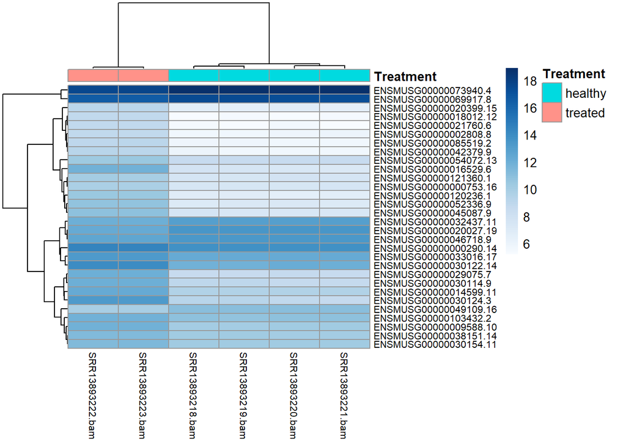

```r
rld <- rlog(dds, blind=FALSE)
pheatmap(assay(rld)[top_hits,],
         cluster_rows=TRUE,
         show_rownames=TRUE,
         cluster_cols=TRUE,
         annotation_col=sample_info,
         color=colorRampPalette(brewer.pal(9, "Blues"))(100),
         fontsize_row=8,
         fontsize_col=8)
```

#Log transform FPKM data

```r
log_fpkm_data <- log2(fpkm_data + 1)
```

#Calculate Z-scores

```r
cal_z_score <- function(x) {(x - mean(x)) / sd(x)}
zscore_all <- t(apply(log_fpkm_data, 1, cal_z_score))
zscore_subset <- zscore_all[top_hits,]
```

#Heatmap of log-transformed FPKM values for the top 30 genes

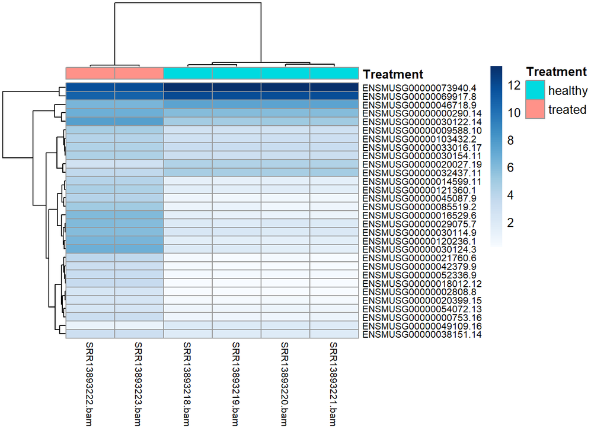

```r
pheatmap(log_fpkm_data[top_hits,],
         cluster_rows=TRUE,
         show_rownames=TRUE,
         cluster_cols=TRUE,
         annotation_col=sample_info,
         color=colorRampPalette(brewer.pal(9, "Blues"))(100),
         fontsize_row=8,
         fontsize_col=8)
```

#Heatmap of Z-scores for the top 30 genes

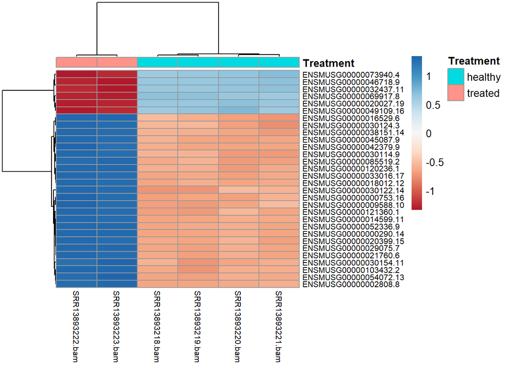

```r
pheatmap(zscore_subset,
         cluster_rows=TRUE,
         show_rownames=TRUE,
         cluster_cols=TRUE,
         annotation_col=sample_info,
         color=colorRampPalette(brewer.pal(9, "RdBu"))(100),
         fontsize_row=8,
         fontsize_col=8)
```

#Select Top 30 Genes with the Lowest Adjusted p-Values (padj) # Order results by padj (adjusted p-value)

```r
deseq_result_ordered <- deseq_result[order(deseq_result$padj),]
```

#Select top 30 genes with the lowest padj values

```r
top_hits <- row.names(deseq_result_ordered)[1:30]
```

#Perform regularized log transformation

```r
rld <- rlog(dds, blind=FALSE)
```

#Heatmap of log-transformed counts for the top 30 genes

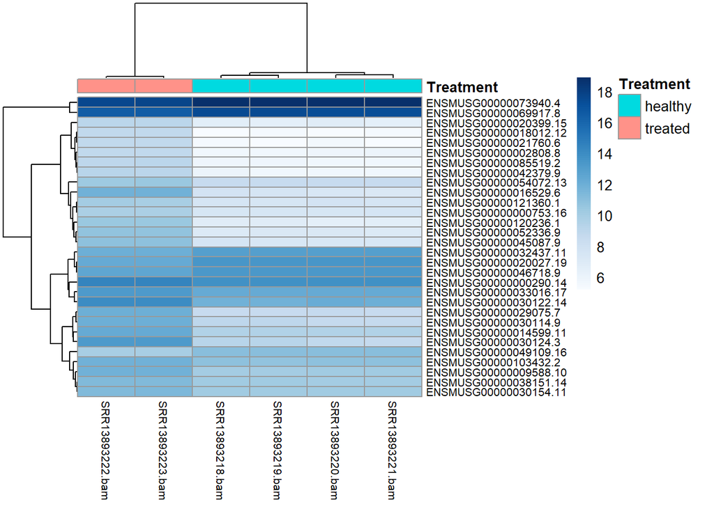

```r
pheatmap(assay(rld)[top_hits,],
         cluster_rows=TRUE,
         show_rownames=TRUE,
         cluster_cols=TRUE,
         annotation_col=sample_info,
         color=colorRampPalette(brewer.pal(9, "Blues"))(100),
         fontsize_row=8,
         fontsize_col=8)
```